# Untitled

Brian Waite

December 23, 2018

## Test Code

#### Setup Analysis Environment

This needs the libraries “reshape” and “ggplot2”

```r
library(reshape2)
library(ggplot2)
```

Read in the two data files. Requires they be in the working directory of this file.

```r
Beers = read.csv("Beers.csv", stringsAsFactors = FALSE)
Breweries = read.csv("Breweries.csv", stringsAsFactors = FALSE)
```

Normalize the variable names in the two data sets

Remove leading spaces from States

```r
Breweries$State = trimws(Breweries$State)
```

### Answer Question 1:

How many breweries are present in each state

```r
BreweriesPerState = as.data.frame(table(Breweries$State))
#rename
names(BreweriesPerState) = c("State", "Num of Breweries")
#display
knitr::kable(BreweriesPerState)
```

| State | Num of Breweries |
| --- | --- |
| AK | 7 |
| AL | 3 |
| AR | 2 |
| AZ | 11 |
| CA | 39 |
| CO | 47 |
| CT | 8 |
| DC | 1 |
| DE | 2 |
| FL | 15 |
| GA | 7 |
| HI | 4 |
| IA | 5 |
| ID | 5 |
| IL | 18 |
| IN | 22 |
| KS | 3 |
| KY | 4 |
| LA | 5 |
| MA | 23 |
| MD | 7 |
| ME | 9 |
| MI | 32 |
| MN | 12 |
| MO | 9 |
| MS | 2 |
| MT | 9 |
| NC | 19 |
| ND | 1 |
| NE | 5 |
| NH | 3 |
| NJ | 3 |
| NM | 4 |
| NV | 2 |
| NY | 16 |
| OH | 15 |
| OK | 6 |
| OR | 29 |
| PA | 25 |
| RI | 5 |
| SC | 4 |
| SD | 1 |
| TN | 3 |
| TX | 28 |
| UT | 4 |
| VA | 16 |
| VT | 10 |
| WA | 23 |
| WI | 20 |
| WV | 1 |
| WY | 4 |

### Answer Question 2: Merge the two data frames. Print first and last 6 observations.

```r
# Set a common Brewery ID variable to merge on:

names(Breweries)[1] = "Brewery_id"

# Merge the two dataframes

MergedBrewing = merge(Beers,Breweries, by = "Brewery_id")

# Fix the names conflict

names(MergedBrewing)[2] = "Beer Name"
names(MergedBrewing)[8] = "Brewery Name"
```

Display the first 6 rows:

```r
knitr::kable(head(MergedBrewing,6))
```

| Brewery_id | Beer Name | Beer_ID | ABV | IBU | Style | Ounces | Brewery Name | City | State |
| --- | --- | --- | --- | --- | --- | --- | --- | --- | --- |
| 1 | Get Together | 2692 | 0.045 | 50 | American IPA | 16 | NorthGate Brewing | Minneapolis | MN |
| 1 | Maggie’s Leap | 2691 | 0.049 | 26 | Milk / Sweet Stout | 16 | NorthGate Brewing | Minneapolis | MN |
| 1 | Wall’s End | 2690 | 0.048 | 19 | English Brown Ale | 16 | NorthGate Brewing | Minneapolis | MN |
| 1 | Pumpion | 2689 | 0.060 | 38 | Pumpkin Ale | 16 | NorthGate Brewing | Minneapolis | MN |
| 1 | Stronghold | 2688 | 0.060 | 25 | American Porter | 16 | NorthGate Brewing | Minneapolis | MN |
| 1 | Parapet ESB | 2687 | 0.056 | 47 | Extra Special / Strong Bitter (ESB) | 16 | NorthGate Brewing | Minneapolis | MN |

And the last 6 rows:

```r
knitr::kable(tail(MergedBrewing,6))
```

|  | Brewery_id | Beer Name | Beer_ID | ABV | IBU | Style | Ounces | Brewery Name | City | State |
| --- | --- | --- | --- | --- | --- | --- | --- | --- | --- | --- |
| 2405 | 556 | Pilsner Ukiah | 98 | 0.055 | NA | German Pilsener | 12 | Ukiah Brewing Company | Ukiah | CA |
| 2406 | 557 | Heinnieweisse Weissebier | 52 | 0.049 | NA | Hefeweizen | 12 | Butternuts Beer and Ale | Garrattsville | NY |
| 2407 | 557 | Snapperhead IPA | 51 | 0.068 | NA | American IPA | 12 | Butternuts Beer and Ale | Garrattsville | NY |
| 2408 | 557 | Moo Thunder Stout | 50 | 0.049 | NA | Milk / Sweet Stout | 12 | Butternuts Beer and Ale | Garrattsville | NY |
| 2409 | 557 | Porkslap Pale Ale | 49 | 0.043 | NA | American Pale Ale (APA) | 12 | Butternuts Beer and Ale | Garrattsville | NY |
| 2410 | 558 | Urban Wilderness Pale Ale | 30 | 0.049 | NA | English Pale Ale | 12 | Sleeping Lady Brewing Company | Anchorage | AK |

### Answer Question 3: Report the number of NAs in each column.

```r
# Find number of NAs in each column

knitr::kable(colSums(is.na(MergedBrewing)))
```

|  | x |
| --- | --- |
| Brewery_id | 0 |
| Beer Name | 0 |
| Beer_ID | 0 |
| ABV | 62 |
| IBU | 1005 |
| Style | 0 |
| Ounces | 0 |
| Brewery Name | 0 |
| City | 0 |
| State | 0 |

### Answer Question 4: Compute the median alcohol content and international bitterness unit for each state. Plot a bar chart to compare.

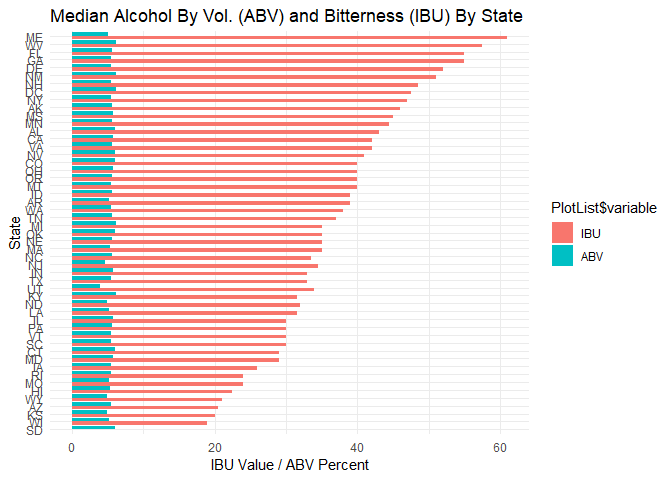

```r
# Get list of states

StateList = unique(MergedBrewing$State)
StateList = as.data.frame(StateList)

# Set up functions to get median IBU and ABV

getStateIBU = function(State) {
  ibuList = MergedBrewing[which(MergedBrewing$State == State),]$IBU
  medianIBU = median(ibuList, na.rm = TRUE)
  return(medianIBU)
  }

getStateABV = function(State) {
  abvList = MergedBrewing[which(MergedBrewing$State == State),]$ABV
  medianABV = median(abvList, na.rm = TRUE)
  return(medianABV)
}

# Now use those functions to get the data and plot

#Add the space in the StateList dataframe for the additional values
StateList$IBU = c(1:length(StateList$State))
StateList$ABV = c(1:length(StateList$State))

#Get the median values for IBU and ABV for each state
for (states in StateList$StateList) {
  StateList[which(StateList$StateList == states),"IBU"] = getStateIBU(states)
  StateList[which(StateList$StateList == states),"ABV"] = getStateABV(states)*100
}

#Get rid of the NA IBU value for South Dakota
StateList[which(is.na(StateList$IBU)),"IBU"] = 0

#Fix the names
names(StateList) = c("State", "IBU", "ABV")

#Now plot the data

PlotList = melt(StateList, id.vars = "State", measure.vars = c("IBU","ABV"))

#Bar plot of the IBU and ABV data by state

library(ggplot2)
ggplot(PlotList, aes(reorder(PlotList$State,PlotList$value), PlotList$value)) +
  geom_bar(aes(fill = PlotList$variable), position = "dodge", stat="identity") + xlab("State") + ylab("IBU Value / ABV Percent") + ggtitle("Median Alcohol By Vol. (ABV) and Bitterness (IBU) By State") + theme(axis.text.x = element_text(angle = 90, hjust = 1)) + theme_minimal() + coord_flip()
```

### Answer Question 5: Which state has the maximum alcoholic (ABV) beer? Which state has the most bitter (IBU) beer?

Output the state with the highest ABV:

```r
knitr::kable(MergedBrewing[which(MergedBrewing$ABV == max(MergedBrewing$ABV, na.rm = TRUE)),"State"])
```

| x |
| --- |
| CO |

Output the state with the most bitter beer:

```r
knitr::kable(MergedBrewing[which(MergedBrewing$IBU == max(MergedBrewing$IBU, na.rm = TRUE)),"State"])
```

| x |
| --- |
| OR |

### Answer Question 6: Summary statistics for the ABV variable.

```r
summary(MergedBrewing$ABV)
```

```
##    Min. 1st Qu.  Median    Mean 3rd Qu.    Max.    NA's
## 0.00100 0.05000 0.05600 0.05977 0.06700 0.12800      62
```

### Answer Question 7: Is there an apparent relationship between the bitterness of the beer and its alcoholic content? Draw a scatter plot.

Looking at the graph below:

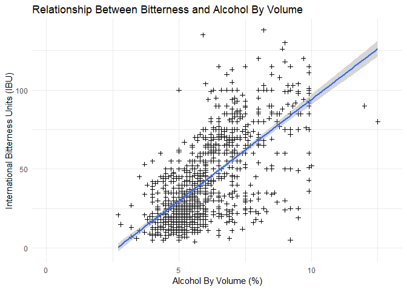

```r
#Scatterplot of ABV vs IBU

#Note: Plot drops NA Values

ggplot(MergedBrewing, aes(x=ABV*100, y=IBU)) +
  geom_point(shape=3) +    # Use hollow circles
  geom_smooth(method=lm) + xlab("Alcohol By Volume (%)") + ylab("International Bitterness Units (IBU)") + ggtitle("Relationship Between Bitterness and Alcohol By Volume") + theme_minimal()
```

It does appear that there is a direct, near linear relationship between the bitterness of a beer and the alcohol content.